# Hw18

# Exercise 16.07

## (a)

```r
read1607 <- read.csv("D:\\Xr16-07.csv")
```

price for dependent variable y and floor for independent variable x

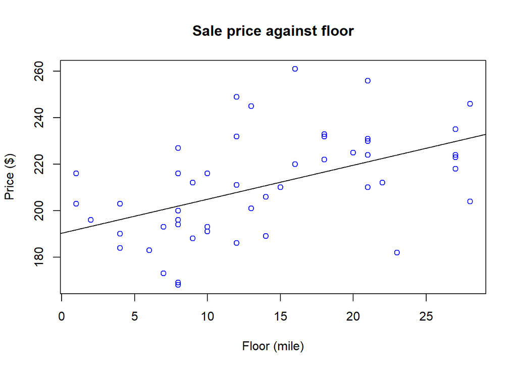

```r
Price <- read1607$Price
Floor <- read1607$Floor
n <- length(Price)
plot(Floor, Price, col = "blue", main = "Sale price against floor", xlab = "Floor (mile)", ylab = "Price ($)")
abline(lm(Price ~ Floor))
```

```r
linearModelVar <- lm(Price ~ Floor)
a <- coef(linearModelVar)[1]
b <- coef(linearModelVar)[2]
se <- sigma(linearModelVar)
Floor_mean <- mean(Floor)
Floor_var <- var(Floor)
print(summary(linearModelVar))
```

```
##
## Call:
## lm(formula = Price ~ Floor)
##
## Residuals:
##     Min      1Q  Median      3Q     Max
## -42.077 -11.741  -2.225  10.693  47.180
##
## Coefficients:
##             Estimate Std. Error t value Pr(>|t|)
## (Intercept)  190.373      5.638  33.766  < 2e-16 ***
## Floor          1.465      0.360   4.071 0.000174 ***
## ---
## Signif. codes:  0 '***' 0.001 '**' 0.01 '*' 0.05 '.' 0.1 ' ' 1
##
## Residual standard error: 19.41 on 48 degrees of freedom
## Multiple R-squared:  0.2566, Adjusted R-squared:  0.2411
## F-statistic: 16.57 on 1 and 48 DF,  p-value: 0.0001742
```

According to the plot we can conclude that the Regression Line we observe is:

y_hat = 190.373+1.465x

## (b)

For each additional floor, the price increases by an average of $1.465

# Exercise 16.13

## (a)

```r
read1613 <- read.csv("D:\\Xr16-13.csv")
```

price for dependent variable y and hours for independent variable x

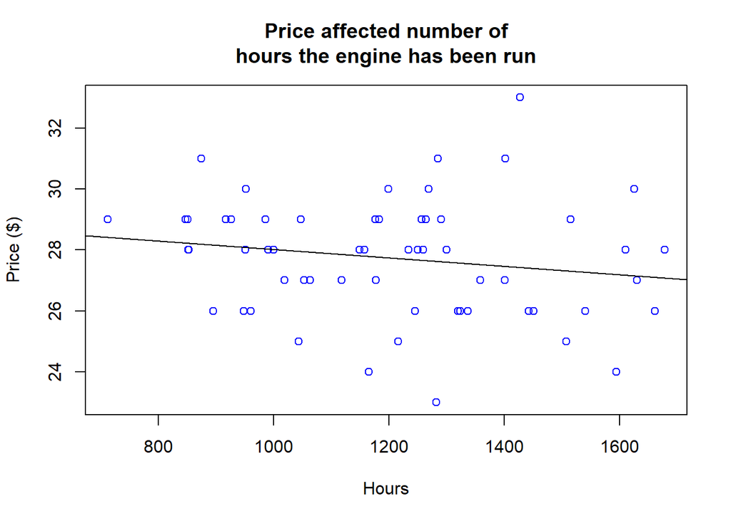

```r
Price <- read1613$Price
Hours <- read1613$Hours
n <- length(Price)
plot(Hours, Price, col = "blue", main = "Price affected number of
hours the engine has been run", xlab = "Hours", ylab = "Price ($)")
abline(lm(Price ~ Hours))
```

```r
linearModelVar <- lm(Price ~ Hours)
a <- coef(linearModelVar)[1]
b <- coef(linearModelVar)[2]
se <- sigma(linearModelVar)
Hours_mean <- mean(Hours)
Hours_var <- var(Hours)
print(summary(linearModelVar))
```

```
##
## Call:
## lm(formula = Price ~ Hours)
##
## Residuals:
##     Min      1Q  Median      3Q     Max
## -4.6188 -1.2929  0.0943  0.9930  5.5816
##
## Coefficients:
##              Estimate Std. Error t value Pr(>|t|)
## (Intercept) 29.391234   1.237137  23.757   <2e-16 ***
## Hours       -0.001383   0.001011  -1.367    0.177
## ---
## Signif. codes:  0 '***' 0.001 '**' 0.01 '*' 0.05 '.' 0.1 ' ' 1
##
## Residual standard error: 1.889 on 58 degrees of freedom
## Multiple R-squared:  0.03121,    Adjusted R-squared:  0.01451
## F-statistic: 1.869 on 1 and 58 DF,  p-value: 0.1769
```

According to the plot we can conclude that the Regression Line we observe is:

y_hat = 29.39123−0.001383x

For each additional hour, the price decreases by an average of $0.001383.

# Exercise 16.21

## Standard Error of estimate

The standard deviation remains constant, but the mean value changes with x.

# Exercise 16.29

According to the plot in 16.07, we can conclude that the Standard Error we observed is 19.41

```r
Price <- read1607$Price
Floor <- read1607$Floor
ybar = mean(Price)
cat("ybar = 210.42")
```

```
## ybar = 210.42
```

Judge the value of 19.41 by comparing it to ybar = 210.42 So (relatively speaking) it appears to be “small”, hence our linear regression model of price as a function of floor is “good”.

## Using descriptive measurements, r2 and r

```r
linearModelVar <- lm(Price ~ Floor)
coe_corr <- cor(Price, Floor)
rsquared <- summary(linearModelVar)$r.squared
cat("# # # # The Coefficient of determination # # # ","\n")
```

```
## # # # # The Coefficient of determination # # #
```

```r
print(rsquared)
```

```
## [1] 0.2566237
```

```r
cat("# # # # The Coefficient of coefficient # # # ","\n")
```

```
## # # # # The Coefficient of coefficient # # #
```

```r
print(coe_corr)
```

```
## [1] 0.5065804
```

```r
cat("# # # # The regression model # # # ","\n")
```

```
## # # # # The regression model # # #
```

```r
print(summary(linearModelVar))
```

```
##
## Call:
## lm(formula = Price ~ Floor)
##
## Residuals:
##     Min      1Q  Median      3Q     Max
## -42.077 -11.741  -2.225  10.693  47.180
##
## Coefficients:
##             Estimate Std. Error t value Pr(>|t|)
## (Intercept)  190.373      5.638  33.766  < 2e-16 ***
## Floor          1.465      0.360   4.071 0.000174 ***
## ---
## Signif. codes:  0 '***' 0.001 '**' 0.01 '*' 0.05 '.' 0.1 ' ' 1
##
## Residual standard error: 19.41 on 48 degrees of freedom
## Multiple R-squared:  0.2566, Adjusted R-squared:  0.2411
## F-statistic: 16.57 on 1 and 48 DF,  p-value: 0.0001742
```

By rsquared = 0.2566237, we can conclude that 25.66237% of the variation in the auction selling price is explained by the variation in floor. The rest remains unexplained by this model.

By r = 0.5065804, we can conclue that there is a moderately strong positive linear relationship (about 50.6%) between the selling price and floor.

## Testing and/or estimating the coefficients

Hypothesis Testing about beta_1

$$H_0: \beta_1 = 0$$

$$H_1: \beta_1 \neq 0$$
According to the plot in 16.07, since p_value = 0.000174, there is sufficient evidence at 5% significance level to infer that there are linear relationship between the two variables.

# Exercise 16.35

$$H_0: \beta_1 = 0$$

$$H_1: \beta_1 < 0$$

```r
Price <- read1613$Price
Hours <- read1613$Hours
linearModelVar <- lm(Price ~ Hours)
a <- coef(linearModelVar)[1]
b <- coef(linearModelVar)[2]
se <- sigma(linearModelVar)
Hours_mean <- mean(Hours)
Hours_var <- var(Hours)
print(summary(linearModelVar))
```

```
##
## Call:
## lm(formula = Price ~ Hours)
##
## Residuals:
##     Min      1Q  Median      3Q     Max
## -4.6188 -1.2929  0.0943  0.9930  5.5816
##
## Coefficients:
##              Estimate Std. Error t value Pr(>|t|)
## (Intercept) 29.391234   1.237137  23.757   <2e-16 ***
## Hours       -0.001383   0.001011  -1.367    0.177
## ---
## Signif. codes:  0 '***' 0.001 '**' 0.01 '*' 0.05 '.' 0.1 ' ' 1
##
## Residual standard error: 1.889 on 58 degrees of freedom
## Multiple R-squared:  0.03121,    Adjusted R-squared:  0.01451
## F-statistic: 1.869 on 1 and 58 DF,  p-value: 0.1769
```

According to the plot, since p_value = 0.177, there is insufficient evidence at 5% significance level to infer that there are linear relationship between the two variables.

# Exercise 16.41

$$H_0: \rho = 0$$

$$H_1: \rho \neq 0$$

```r
Price <- read1613$Price
Hours <- read1613$Hours

test_cor <- cor.test(Price, Hours)

cat("# # # # The test of Coefficient of Correlation # # # ","\n")
```

```
## # # # # The test of Coefficient of Correlation # # #
```

```r
print(test_cor)
```

```
##
##  Pearson's product-moment correlation
##
## data:  Price and Hours
## t = -1.3669, df = 58, p-value = 0.1769
## alternative hypothesis: true correlation is not equal to 0
## 95 percent confidence interval:
##  -0.41210346  0.08088768
## sample estimates:
##        cor
## -0.1766656
```

Since p_value = 0.1769, There is nsufficient evidence at 5% significance level to infer that there are linear relationship between the two variables.

# Exercise 16.47

## (a)

```r
read1647 <- read.csv("D:\\Xr16-47.csv")
```

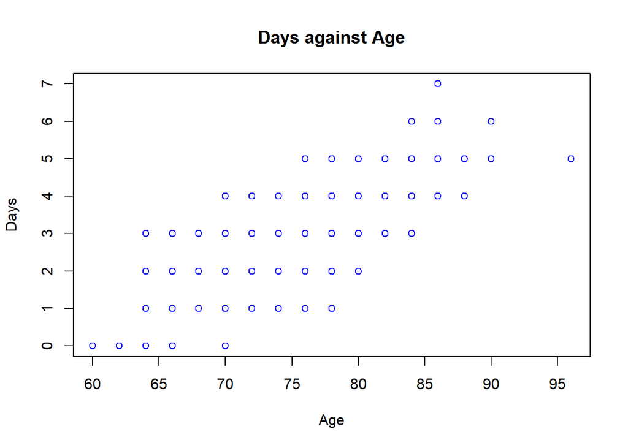

```r
Days <- read1647$Days
Age <- read1647$Age
n <- length(Days)
plot(Age, Days, col = "blue", main = "Days against Age", xlab = "Age", ylab = "Days")
abline(lm(Age ~ Days))
```

```r
linearModelVar <- lm(Age ~ Days)
a <- coef(linearModelVar)[1]
b <- coef(linearModelVar)[2]
se <- sigma(linearModelVar)
Age_mean <- mean(Age)
Age_var <- var(Age)
print(summary(linearModelVar))
```

```
##
## Call:
## lm(formula = Age ~ Days)
##
## Residuals:
##      Min       1Q   Median       3Q      Max
## -12.1385  -2.4731  -0.1385   2.8653  12.5307
##
## Coefficients:
##             Estimate Std. Error t value Pr(>|t|)
## (Intercept)  65.1422     0.5553  117.32   <2e-16 ***
## Days          3.6654     0.1730   21.19   <2e-16 ***
## ---
## Signif. codes:  0 '***' 0.001 '**' 0.01 '*' 0.05 '.' 0.1 ' ' 1
##
## Residual standard error: 3.937 on 318 degrees of freedom
## Multiple R-squared:  0.5854, Adjusted R-squared:  0.5841
## F-statistic:   449 on 1 and 318 DF,  p-value: < 2.2e-16
```

Since p_value < 0.025, there is overwhelming evidence to infer that there is a linear relationship between age and number of days watching national news.

## (b)

```r
Days <- read1647$Days
Age <- read1647$Age

test_cor <- cor.test(Days, Age)

cat("# # # # The test of Coefficient of Correlation # # # ","\n")
```

```
## # # # # The test of Coefficient of Correlation # # #
```

```r
print(test_cor)
```

```
##
##  Pearson's product-moment correlation
##
## data:  Days and Age
## t = 21.189, df = 318, p-value < 2.2e-16
## alternative hypothesis: true correlation is not equal to 0
## 95 percent confidence interval:
##  0.7154831 0.8070444
## sample estimates:
##       cor
## 0.7651041
```

According to r and p_value, there is a very strong positive linear relationship between age and number of days watching national news.